# Investigating exponential distribution in R

Olusegun

6/15/2021

## 1.Overview

In this project we will investigate the exponential distribution in R and compare it with the Central Limit Theorem. The exponential distribution can be simulated in R with `rexp(n, lambda)` where lambda is the rate parameter.

## 2.Simulations

The mean of exponential distribution is 1/lambda and the standard deviation is also 1/lambda. We set lambda = 0.2 for all of the simulations. We will investigate the distribution of averages of 40 exponentials. Note that number of simulations = 1000.

```r
sim <- 1000
n <- 40
lambda <- 0.2
sim_data <- matrix(rexp(n*sim,lambda), sim, n)
```

We will illustrate the properties of the distribution of the mean of 40 exponentials by showing:

- The sample mean and comparing it to the theoretical mean of the distribution.
- How variable the sample is (via variance) and comparing it to the theoretical variance of the distribution
- That the distribution is approximately normal.

## 3.Sample Mean versus Theoretical Mean

Showing the sample mean and comparing it to the theoretical mean of the distribution.

```r
sample_mean <- apply(sim_data, 1, mean)
sim_mean <- mean(sample_mean)
theoretical_mean <- 1/lambda

  result1 <-data.frame("Mean"=c(sim_mean,theoretical_mean),
                       row.names = c("Sample Mean","Theoretical mean"))
  result1
```

```
##                      Mean
## Sample Mean      5.013579
## Theoretical mean 5.000000
```

The simulation mean of 5.013579 is close to the theoretical value of 5.

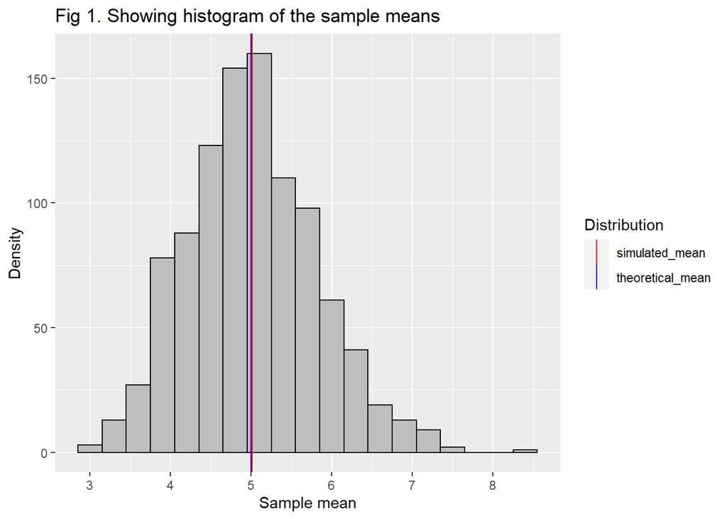

```r
library(ggplot2)
    g = ggplot(data.frame(sample_mean=sample_mean), aes(x = sample_mean))
    g = g + geom_histogram(color = "black", fill = "grey", binwidth = 0.3)
    g = g + geom_vline(aes(xintercept = theoretical_mean,
                           colour="theoretical_mean"))
    g = g + geom_vline(aes(xintercept = sim_mean,colour="simulated_mean"))
    g = g +  scale_color_manual(name = "Distribution",
                                values = c(theoretical_mean = "blue",
                                           simulated_mean = "red"))
    g = g +ggtitle ("Fig 1. Showing histogram of the sample means ")+xlab("Sample mean")+ylab("Density")
    g
```

*The figure above shows the histogram of the sample means. It also shows where the distribution is centered at and also, the theoretical center of the distribution.*

## 4.Sample Variance versus Theoretical Variance

Showing how variable the sample is (via variance) and comparing it to the theoretical variance of the distribution.

```r
sample_variance <- (apply(sim_data, 1, sd))^2
sim_variance <- mean(sample_variance)
theoretical_variance <- (1/lambda)^2

  result2 <-data.frame("Variance"=c(sim_variance,theoretical_variance),
                       row.names = c("Sample Variance","Theoretical Variance"))
  result2
```

```
##                      Variance
## Sample Variance      24.95488
## Theoretical Variance 25.00000
```

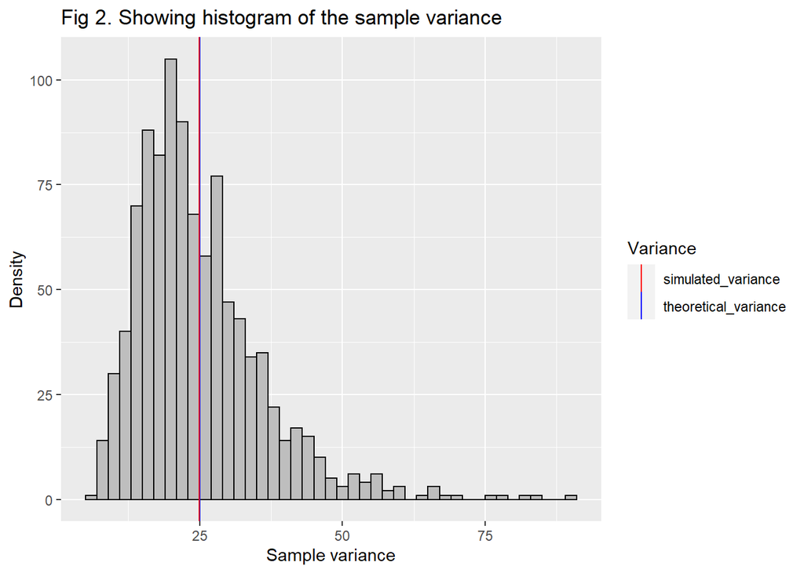

```r
    g = ggplot(data.frame(sample_variance=sample_variance), aes(x = sample_variance))
    g = g + geom_histogram(color = "black", fill = "grey", binwidth = 2)
    g = g + geom_vline(aes(xintercept = theoretical_variance,colour="theoretical_variance"))
    g = g + geom_vline(aes(xintercept = sim_variance,colour="simulated_variance"))
    g = g +  scale_color_manual(name = "Variance",
                                values = c(theoretical_variance = "blue",
                                           simulated_variance = "red"))
    g = g +ggtitle ("Fig 2. Showing histogram of the sample variance")+xlab("Sample variance")+ylab("Density")
    g
```

*The simulation variance of 24.9548848 is close to the theoretical value of 25.*

## 5.Distribution

Showing that the distribution is approximately normal.

According to the central limit theorem (CLT), the averages of samples follow normal distribution.

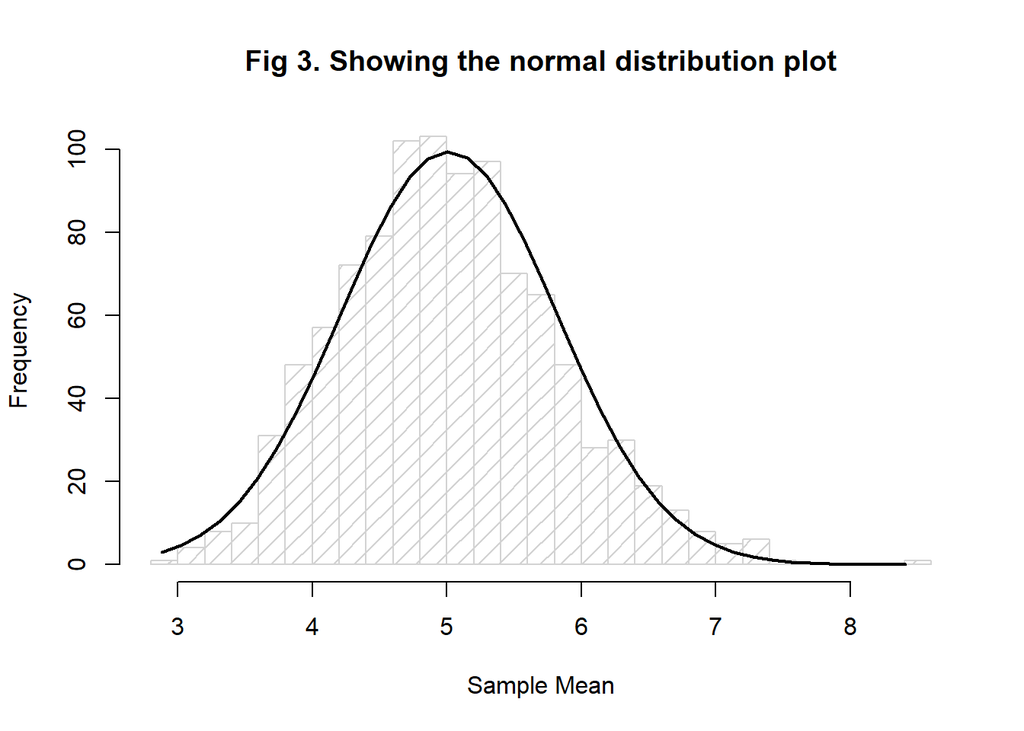

```r
h <- hist(sample_mean, breaks = 20, density = 10,
          col = "lightgray", xlab = "Sample Mean", main = "Fig 3. Showing the normal distribution plot")
xfit <- seq(min(sample_mean), max(sample_mean), length = 40)
yfit <- dnorm(xfit, mean = mean(sample_mean), sd = sd(sample_mean))
yfit <- yfit * diff(h$mids[1:2]) * length(sample_mean)

lines(xfit, yfit, col = "black", lwd = 2)
```

*The plot above shows that the distribution of the sample means almost matches the normal distribution.*

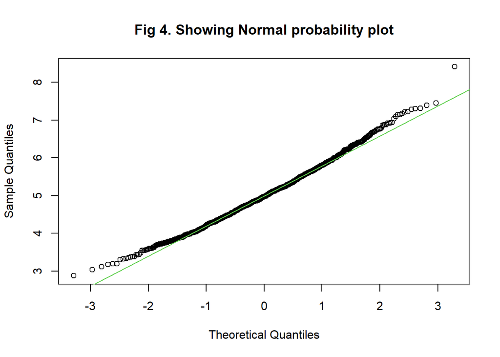

```r
qqnorm(sample_mean, main ="Fig 4. Showing Normal probability plot")
qqline(sample_mean,col = "3")
```